# 15. Association tests

Lorenzo Bertola

Document last run on 2022-11-03

## 1. Background

We have identified a region that is a very good candidate for harbouring the sex-determination locus on LG6.

To further validate our findings, let’s now conduct an association test for each SNP from the adult sexed individuals dataset. We will then plot the statistical significance of association for each SNP against their linkage map position to see whether we detect the same region as we did using the sex-linked markers.

We will use the package [SNPassoc](https://doi.org/10.1093/bioinformatics/btm025).

Load required packages

```r
library(SNPassoc)
library(xtable)
library(tidyverse)
library(janitor)
```

### 2. Convert to ped format

Read genotype data for the adult sexed individuals

```r
my.df <- readRDS(file = "../3_SexLinked/13_2_InputDataframe_sex_R40.RData")
```

First we remove "_a" from the end of sample IDs, as we don’t need the replicate info anymore and it makes life harder. Remember, we have already retained one replicate per sample.

```r
names(my.df) <- gsub(pattern = "_a",
                     replacement = "",
                     x = names(my.df))

names(my.df) <- gsub(pattern = "_b",
                     replacement = "",
                     x = names(my.df))
```

Transpose to have individuals as rows:

```r
my.df <- as.data.frame(t(my.df))

my.df <- row_to_names(my.df, row_number = 1)

my.df <- rownames_to_column(my.df, var = "sampleID")
```

Add columns required for ped file (I am using the RIGHT function by Andrew Haynes found [here](https://stackoverflow.com/questions/7963898/extracting-the-last-n-characters-from-a-string-in-r) )

```r
RIGHT = function(x,n){
  substring(x,nchar(x)-n+1)
}
```

```r
my.df <- my.df %>%
  add_column(FAM="FAM", .before = 'sampleID') %>%
  add_column(father=0, .after =  'sampleID') %>%
  add_column(mother=0, .after =  'father') %>%
  mutate(sex=case_when(RIGHT(sampleID,2)=="F1" ~ 2,
                       RIGHT(sampleID,2)=="M1" ~ 1),
         .after = 'mother') %>%
  mutate(sex2=case_when(RIGHT(sampleID,2)=="F1" ~ 2,
                       RIGHT(sampleID,2)=="M1" ~ 1),
         .after = 'mother')
```

extract genotype columns to recode in plink format

```r
gens <- my.df[,7:ncol(my.df)]

gens[gens==-1]<-NA
gens[gens==" 0"]<-"AA"
gens[gens==" 1"]<-"AC"
gens[gens==" 2"]<-"CC"
```

Make final dataset

```r
my.df <- cbind(my.df %>% select(sampleID,sex),gens)
```

Remove unnecessary objects

```r
rm(gens, RIGHT)
```

Save the resulting file

```r
write_delim(my.df, file = "../3_SexLinked/15_2_SNPassoc_Input.txt",
            delim = "\t")
```

### 3. Association test

Convert to SNPassoc data format

```r
sex <- setupSNP(data=my.df, colSNPs=3:ncol(my.df), sep="")
```

Conduct association test for all markers using the codominant model. We will do it only for bi-allelic markers where at least 60% of adults were genotyped.

```r
WGcod <- WGassociation(sex, data = sex, model = "codominant",
              quantitative = FALSE, genotypingRate = 60)
```

Save the resulting files

```r
write_delim(x = cbind("SNPID"=rownames(WGcod),WGcod), file = "../3_SexLinked/15_3_SNPassoc_Output_Raw.txt",
            delim = "\t",)

saveRDS(WGcod,file = "../3_SexLinked/15_3_SNPassoc_Output_Raw.RData")
```

Format output of association test, retaining only rows where markers were biallelic and had a call rate > 60% (those for whome a pvalue was calculated)

```r
WGcod <- readRDS(file = "../3_SexLinked/15_3_SNPassoc_Output_Raw.RData")
```

```r
WGcod <- cbind("SNPID"=rownames(WGcod),WGcod)

WGcod <- WGcod %>%
  filter(is.na(comments)==TRUE & is.na(codominant)==FALSE) %>%
  mutate(SNPID=gsub("X","",SNPID)) %>%
  rename("pvalue"=codominant)
```

Add adjusted pvalues using bonferroni and FDR

```r
bonf <- p.adjust(WGcod$pvalue, method = "bonferroni")

FDR <- p.adjust(WGcod$pvalue, method = "fdr")

BH <- p.adjust(WGcod$pvalue, method = "BH")

WGcod <- cbind(WGcod,bonf,FDR, BH)

rm(FDR,bonf,BH)
```

Filter to retain only markers associated with sex at an alpha value of 0.01 (not stringent for now).

```r
WGcod2 <- WGcod %>% filter(pvalue < 0.01)
```

Read in sex-linked markers to compare and see if the same markers were identified

```r
my.sexLinked <- read_delim("../3_SexLinked/13_3_SexLinkedMarkers_DM_2.txt",
                           delim = "\t")
```

See what markers that are associated with sex were detected with sex-linkage method as well

```r
WGcod3 <- full_join(my.sexLinked, WGcod2, by = c("markerID" = "SNPID")) %>% select(-comments)
```

How many sex-linked markers are also associated with sex at an alpha value of 0.01?

```r
WGcod3 %>% filter(is.na(Method)==FALSE & is.na(pvalue)==FALSE) %>% nrow()
```

```
## [1] 38
```

How many that are sex-linked are not associated with sex?

```r
WGcod3 %>% filter(is.na(Method)==FALSE & is.na(pvalue)==TRUE) %>% nrow()
```

```
## [1] 3
```

Only 3, let’s see which ones

```r
WGcod3 %>% filter(is.na(Method)==FALSE & is.na(pvalue)==TRUE) %>% select(markerID, Method, SexDet)
```

```
## # A tibble: 3 × 3
##   markerID Method  SexDet
##   <chr>    <chr>   <chr>
## 1 19156_57 Method1 XY
## 2 28477_31 Method1 ZW
## 3 12700_56 Method5 ZW
```

One XY marker and the only two ZW markers.

Now, how many are associated with sex but were not detected with heterozygosity methods?

```r
WGcod3 %>% filter(is.na(pvalue)==FALSE & is.na(Method)==TRUE) %>% nrow()
```

```
## [1] 42
```

Fourty-two. At the moment we do not have their genotype counts. Let’s retrieve them and add them to the table.

```r
my.gcounts <- readRDS("../3_SexLinked/13_2_SexGenotypeCounts.RData")
```

Let’s join the genotype counts dataframe with the GWAS dataframe

```r
temp <- WGcod3 %>%
  filter(is.na(pvalue)==FALSE & is.na(Method)==TRUE) %>%
  select(markerID, pvalue:BH)

temp <- left_join(my.gcounts,temp, by="markerID") %>%
  filter(is.na(pvalue)==FALSE)
```

Now let’s add columns to match the columns of WGcod3. These include info on sexdetermination detected and method used (they will be NA for this data as they were not detected as sex-linked), as well as linkage map positions

```r
temp <- temp %>%
  add_column("Method"=NA, .after = "Snp_F") %>%
  add_column("SexDet"=NA, .before = "pvalue") %>%
  mutate("Locus"= gsub("\\_.*","",markerID), .before="pvalue")
```

Now add LG, male position and female position information from matching markerIDs.

Read in linkage map data

```r
my.map <- read_delim("../2_LinMap/10_4_linkageMap.txt",
                     delim = "\t")
temp2 <- my.map %>% dplyr::select(SNPID,LG,male,female)

temp <- left_join(temp,temp2,
                          by = c("markerID"="SNPID"))

rm(temp2)
```

Now, add LG, male position and female position information from matching Locus IDs.

```r
temp2 <- my.map %>%
  dplyr::select(Locus,LG,male,female) %>%
  group_by(Locus) %>%
  summarise(LG = mean(LG),
            mean_F = mean(female),
            mean_M = mean(male))

temp2 <- temp2 %>%
  mutate(Locus = as.character(Locus))

temp <- left_join(temp, temp2,
                          by = "Locus",
                          suffix = c("_marker",
                                     "_locus"))

rm(temp2)
```

Rearrange to match column order in WGcod3

```r
temp <- temp %>% select(markerID:Locus,LG_marker:mean_M, pvalue:BH)
```

Now join the two datasets, containing sex-linked markers (box sex associated and non sex associated), and all remaining sex assocaited markers.

```r
temp2 <- rbind(WGcod3 %>% filter(is.na(Method)==FALSE),
               temp)
```

Clean working environment

```r
my.both <- temp2

rm(temp, temp2, my.gcounts,my.sexLinked, WGcod, WGcod2, WGcod3)
```

Save the resulting file

```r
write_delim(x = my.both, file = "../3_SexLinked/15_3_SNPassoc_And_SexLinked.txt",
            delim = "\t",)
```

### 3.3. Plot significance across linkage map

Now, let’s plot the results on the linkage map.

Read in SNPassoc output

```r
WGcod <- read_delim("../3_SexLinked/15_3_SNPassoc_Output_Raw.txt",
                    delim = "\t")
```

Format a little

```r
WGcod <- WGcod %>%
  mutate(SNPID = gsub("X","",SNPID)) %>%
  filter(is.na(comments)==TRUE & is.na(codominant)==FALSE) %>%
  rename("pvalue" = codominant) %>%
  mutate(pvalue2 = (-log10(pvalue)))
```

Add column of alternating colour to the linkage map

```r
my.map <- my.map %>% mutate(colour = case_when(LG %% 2 == 0 ~ "black",
                                          LG %% 2 != 0 ~ "red"))
```

Now join to retain only markers present on both the linkage map and the sexed adult dataset. We will also add a column with -log10 of the pvalue

```r
my.df.2 <- left_join(WGcod, my.map, by = "SNPID") %>%
  filter(is.na(LG)==FALSE)
```

Now let’s plot pvalue versus linkage map position by chromosome.

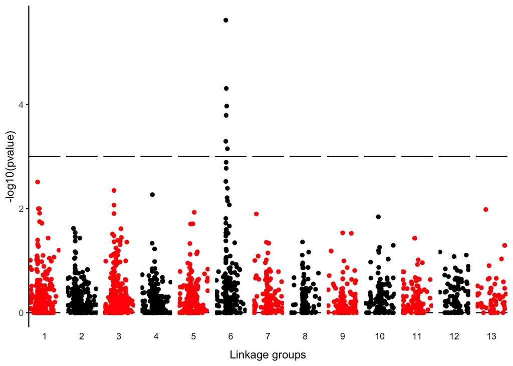

```r
p1 <- ggplot(my.df.2, aes(x = sex.averaged, y=pvalue2, )) +
  #geom_histogram(binwidth = 1, aes(fill=colour, col=colour)) +
  geom_hline(yintercept=0) +
  geom_point(aes(fill=colour, col=colour)) +
  facet_grid(~LG, scales = "free_x", switch = "x") +
  geom_hline(yintercept=(-log10(0.001))) +
  theme_classic() +
  scale_fill_manual(values = c("black","red")) +
  scale_color_manual(values = c("black","red")) +
  theme(axis.text.x = element_blank(),
        axis.ticks.x = element_blank(),
        axis.line.x = element_blank(),
        strip.background = element_blank(),
        legend.position = "none") +
  labs(y = "-log10(pvalue)", x = "Linkage groups")

p1
```

Now let’s plot pvalue versus linkage map position for LG6 only. And let’s highlight markers that were identified by Methods 1 to 5 as well.

```r
bothIDs <- my.both %>% filter(is.na(SexDet)==FALSE) %>% pull(markerID)
```

Assign an extra column stating whether those markers were identified by sex-linkage methods as well.

```r
my.df.2 <- my.df.2 %>%
  mutate(sexlinked=if_else(SNPID%in%bothIDs,"Sex-linked","not Sex-linked"))
```

Plot linkage group 6

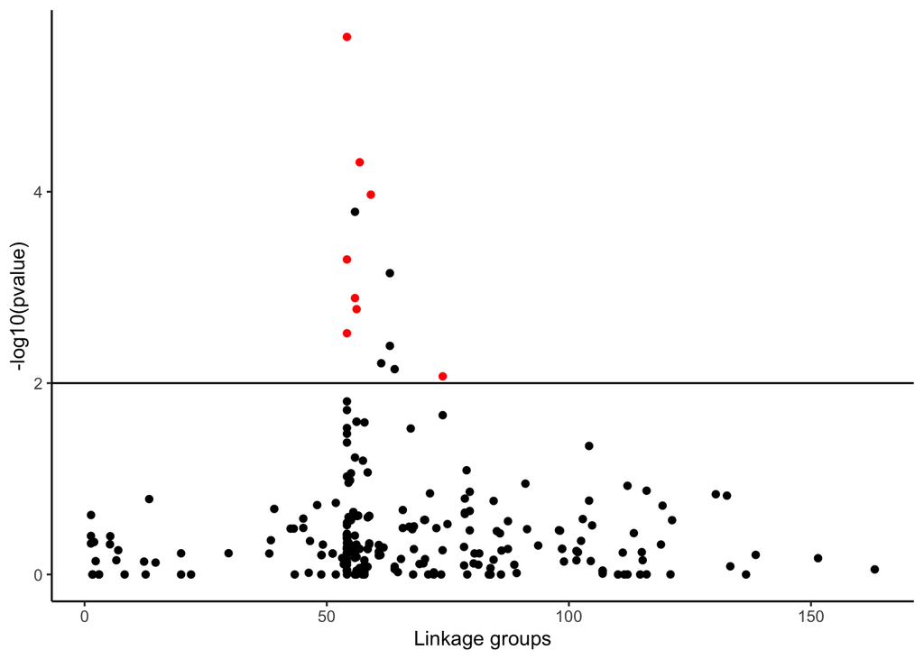

```r
p2 <- ggplot(my.df.2 %>% filter(LG==6), aes(x = sex.averaged, y=pvalue2)) +
  geom_point(aes(fill=sexlinked, col=sexlinked)) +
  geom_hline(yintercept=(-log10(0.01))) +
  theme_classic() +
  scale_fill_manual(values = c("black","red")) +
  scale_color_manual(values = c("black","red")) +
  theme(strip.background = element_blank(),
        legend.position = "none",
        panel.spacing.x = unit(0,"lines"),
        panel.spacing.y = unit(1,"lines")) +
  labs(y = "-log10(pvalue)", x = "Linkage groups")

p2
```

```r
ggsave("../3_SexLinked/15_3_SignificanceByLG.jpeg",p1,device = "jpeg",dpi=600,
       width = 8, height = 4)
ggsave("../3_SexLinked/15_3_SignificanceLG6.jpeg",p2,device = "jpeg",dpi=600,
       width = 8, height = 4)
```

### 3.4. Sex-linked markers contingency tables

Now let’s try and export the contingency tables of sex-ilnked and sex associated markers only.

```r
WGcod <- readRDS("../3_SexLinked/15_3_SNPassoc_Output_Raw.RData")
```

Obtain list of unique marker IDs from sex-linked and sex-associated markers

```r
IDs <- my.both %>% pull(markerID) %>% unique()

IDs <- paste0("X",IDs)
```

```r
out <- getNiceTable(WGcod[IDs])

nlines <- attr(out, "nlines")
hlines <- c(-1, -1, 0, cumsum(nlines+1), nrow(out), nrow(out))

print(xtable(out, caption='Genetic association using
                different genetic models from asthma
                data example of X32707_50 and X334_26
                SNPs obtained with SNPassoc.',
             label = 'tab-2SNPs'),
      tabular.enviroment="longtable",
      file="../3_SexLinked/15_4_SNPassoc_ContingencyTables",
      floating=FALSE,  include.rownames = FALSE,
      hline.after= hlines, sanitize.text.function=identity)
```